# Scanning parameter grid to understand circadian clock model

Ye Yuan

2025-04-22

This vignette documents the `grid_scan()` function provided in this package which allows high-performance repeated simulation runs over a grid of parameters and/or initial states. Here, we take the classical LG circadian clock model and demonstrate the following:

1. Under a wide range of initial states, LG model converges to a determined limit cycle attractor reflecting the circadian clock.
2. Such stability holds even when model parameters changes (albeit shape/period of the attractor will change).

Workflow shown here shall be generally useful for interpretation of wet-lab experiment results as study of clock mutants typically ends up with hypotheses where certain parameter(s) of the circadian clock is/are affected.

`grid_scan()` is generally useful for cases where you have an Odin model too; this function is decoupled from specifics of circadian clock models.

```r
library(clockSim)
library(matrixStats)
library(dplyr)
```

## Baseline: a limit cycle oscillator

Under wildtype condition the circadian clock is a limit cycle oscillator with ~24hr period. The LG model reproduces such behavior. To see this we run simulation with default setting:

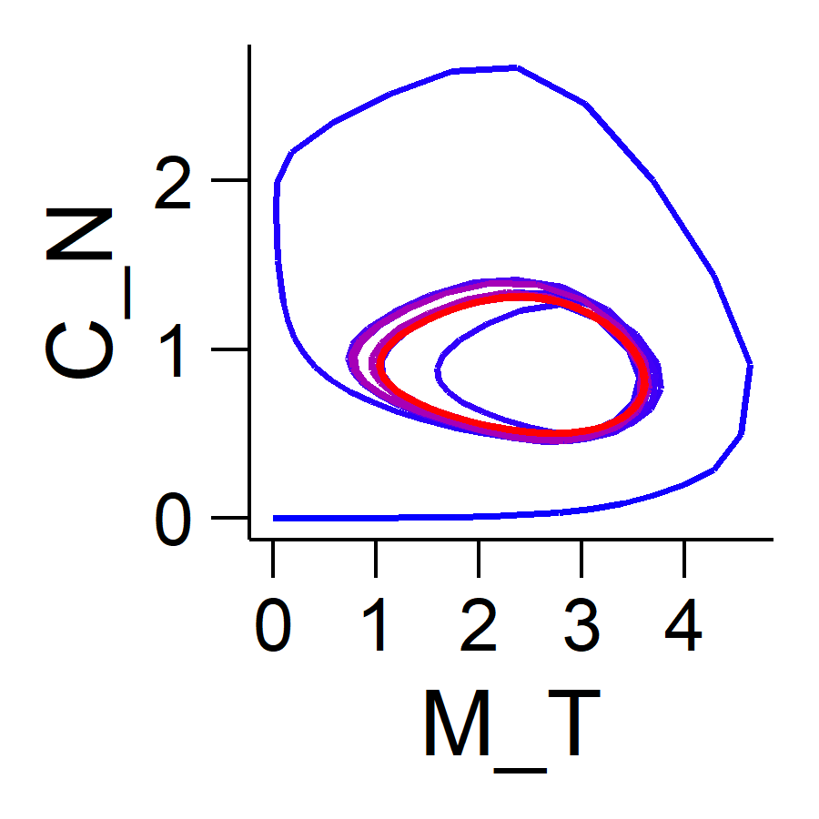

```r
model_gen <- getOdinGen()$continuous_LG
model <- model_gen$new()

sim_hours <- seq(from = 0, to = 2400, by = 1)
res <- model$run(sim_hours) |> as.data.frame()
res$time <- res$t
plot(plot_phase(res, M_T, C_N))
```

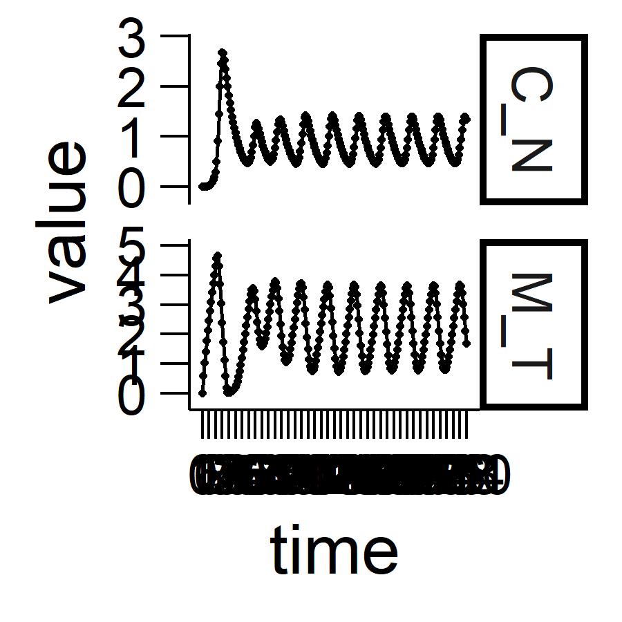

```r
plot(plot_timeSeries(res, 0, 240, 1, 6, M_T, C_N))
```

```r
print(compute_period(res$M_T |> tail(n = 240), method = "lomb"))
```

```
#>        period         power           snr       p.value
#>  2.390000e+01  8.558178e-01            NA 2.142988e-100
```

As shown above:

1. A stable limit cycle attractor is observed.
2. First 10 days show stabilization against the all-0 initial state.
3. Last 10 days show a 23.9hr period reflecting a circadian clock.

While promising, however, the LG model is a complex 10-state system. We next explore different properties of the system:

1. Would different initial states always lead to the clock limit cycle?
2. Would increase/decrease of parameters disrupt the attractor?

## Initial state grid scan

10-variable makes it impossible to do a extensive grid on initial states. To see how fast our simulation runs:

```r
run_eta(model, sim_hours)
```

```
#> Median run time = 10.7ms
```

With each simulation at ~10ms, we should be able to do 1) a very coarse grid on all 10 states with ~3 for each state, or 2) an extensive grid on selected states (say TIM/PER RNA):

$$3^{10}*10\mbox{ms}\sim 250^{2}*10\mbox{ms}\sim600\mbox{sec}$$

With the CRAN build time limitation, in this vignette we will not run the ~10min grid above but instead deal with a smaller grid on TIM/PER RNA.

### Grid generation

```r
# Compute summary
summary <- res |>
  select(-t, -time) |>
  apply(2, summary)
# Only keep min/mean/max
summary <- summary[c(1,4,6),]
# Add on mean+N*spread, N=2,3,...,N_max
N_max <- 3 # For larger scan increase this. CRAN=3
get_multiples <- function(s, k) {
  # Extract components
  min <- s[1, ]
  mean <- s[2, ]
  delta <- s[3, ] - min

  # Create new rows using vectorized operations
  multiples <- outer(k, delta) |> sweep(2, mean, "+")
  attr(multiples, "original") <- s

  # Return
  multiples
}
summary <- get_multiples(summary, 2:N_max)
summary <- summary[,c("M_T", "M_P")] # Only RNA states
# Create grid
grid <- expand.grid(
  summary |> as.data.frame(), KEEP.OUT.ATTRS = FALSE)
#   User variables for initial state start with setUserInitial_
names(grid) <- paste0("setUserInitial_",names(grid))
```

### Running `grid_scan()`

Now perform grid scan of initial states. `grid_scan()` is designed for efficient repeated model execution on parameter grid. Refer to its help for more details, and here I summarize its design concept:

1. Allow scanning arbitrary grid generated by, e.g., `expand.grid()`.
2. Parallel computing based on base R `parallel`.
3. Return raw run data or allow user to apply a summary function (to reduce memory load).

We want the following statistics:

1. Did the simulation converge (i.e., successful integration)?
2. Did the simulation fall into the “default” attractor (i.e., the solution when initial states are all-zero default)? For this, we compute max NRMSE (among states) and min cosine similarity (among simulation time) to capture the largest deviation. For explanation of these metrics, refer to `?compute_rmse` and `?compute_cosine`.

These statistics mean we apply the following function to each run data:

```r
default_attractor <- model_gen$new()$run(sim_hours)
default_attractor <-
  default_attractor[(length(sim_hours)-240):length(sim_hours),]
stat.fn <- function(raw_run, reference = default_attractor){
  # Return code == 2 means successful integration (at least for lsoda)
  succ <- attr(raw_run, "istate")[1] == 2
  # Subset only the last 240 time points - should be stabilized
  raw_run <- raw_run[(nrow(raw_run)-240):nrow(raw_run),]
  # Compute normalized RMSE
  nrmse <- compute_rmse(raw_run, reference, normalize = "range")
  nrmse <- max(nrmse)
  # Compute cosine similarity
  cos <- compute_cosine(raw_run, reference)
  cos <- min(cos)
  # Return
  c(converged = succ, nrmse = nrmse, cos = cos)
}
```

```r
print(bench::mark(stat.fn(model$run(sim_hours))))
```

```
#> # A tibble: 1 × 13
#>   expression      min median `itr/sec` mem_alloc `gc/sec` n_itr  n_gc total_time
#>   <bch:expr>   <bch:> <bch:>     <dbl> <bch:byt>    <dbl> <int> <dbl>   <bch:tm>
#> 1 stat.fn(mod… 10.7ms 11.2ms      87.6    1.35MB        0    44     0      502ms
#> # ℹ 4 more variables: result <list>, memory <list>, time <list>, gc <list>
```

```r
print(bench::mark(model$run(sim_hours)))
```

```
#> # A tibble: 1 × 13
#>   expression      min median `itr/sec` mem_alloc `gc/sec` n_itr  n_gc total_time
#>   <bch:expr>   <bch:> <bch:>     <dbl> <bch:byt>    <dbl> <int> <dbl>   <bch:tm>
#> 1 model$run(s… 10.1ms 10.4ms      94.8     735KB        0    48     0      506ms
#> # ℹ 4 more variables: result <list>, memory <list>, time <list>, gc <list>
```

Now let’s run the grid scan of initial states. We run `grid_scan`, and then wrangle the results into a data frame. As below, all converged to the same attractor.

```r
scan <-
  grid_scan(model_gen, grid, apply.fn = stat.fn,
            n.core = 1, custom.export = "default_attractor",
            sim_hours)

process_scan <- function(){
  .scanDF <- scan |> unlist(use.names = FALSE) |> matrix(ncol = 3, byrow=TRUE)
  colnames(.scanDF) <- names(scan[[1]])
  result <- cbind(grid, .scanDF |> as.data.frame())
  summary(
    result |> select(converged, nrmse, cos)
    )
}

process_scan()
```

```
#>    converged     nrmse                cos
#>  Min.   :1   Min.   :2.178e-05   Min.   :1
#>  1st Qu.:1   1st Qu.:2.674e-05   1st Qu.:1
#>  Median :1   Median :3.498e-05   Median :1
#>  Mean   :1   Mean   :4.622e-05   Mean   :1
#>  3rd Qu.:1   3rd Qu.:5.446e-05   3rd Qu.:1
#>  Max.   :1   Max.   :9.314e-05   Max.   :1
```

Plot two phase diagrams as an example (note that I rerun `grid_scan()` with default `apply_fn = identity` to get the raw data for plotting):

```r
# Rerun scan
scan <-
  grid_scan(model_gen, grid, apply.fn = identity,
            n.core = 1, custom.export = "default_attractor",
            sim_hours)
# Show first and last of grid
first <- grid[1,]
last <- grid[nrow(grid),]
print(first)
```

```
#>   setUserInitial_M_T setUserInitial_M_P
#> 1           11.47733            6.50043
```

```r
print(last)
```

```
#>   setUserInitial_M_T setUserInitial_M_P
#> 4           16.11438           9.314509
```

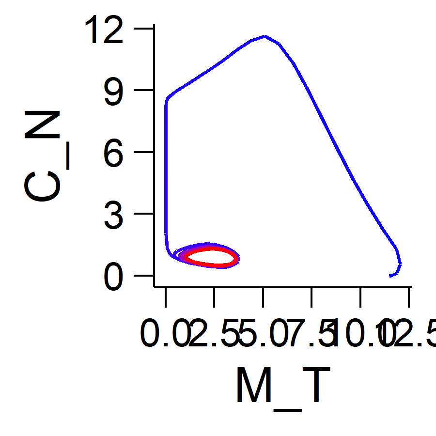

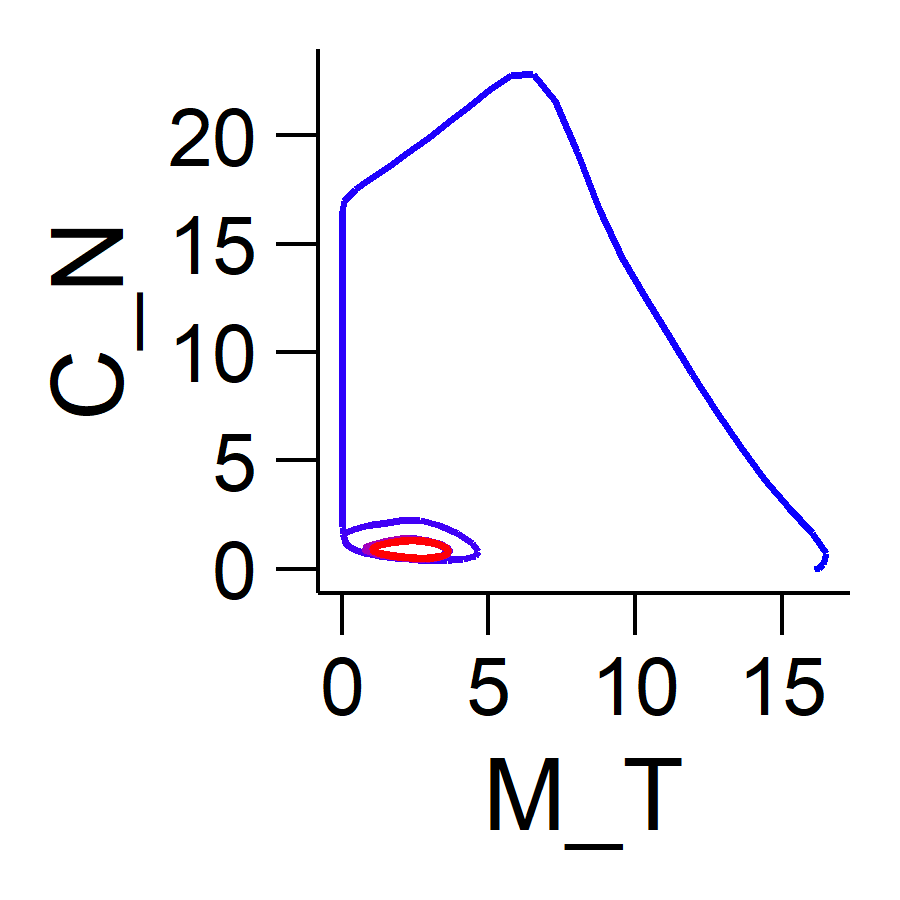

```r
plot(plot_phase(scan[[1]] |> as.data.frame(), M_T, C_N))
plot(plot_phase(scan[[nrow(grid)]] |> as.data.frame(), M_T, C_N))
```

How about modifying one parameter and see if that affects initial state stability with the same grid? Just add that parameter new value as a constant to the grid!

Remember that our goal is to see whether parameter change causes convergence property change - so our reference attractor should be computed with the new parameter too. As below, just as an example, doubling translation rate of TIM mRNA does not affect the behavior - all initial states still converged to the clock attractor.

```r
new_grid <- grid
new_grid$k_sT <- 1.8 # 2X of original, check model$content()
new_model <- model_gen$new()
new_model$set_user(k_sT = 1.8)
default_attractor <- new_model$run(sim_hours)
default_attractor <-
  default_attractor[(length(sim_hours)-240):length(sim_hours),]
# Then, repeat the same code above.
scan <-
  grid_scan(model_gen, new_grid, apply.fn = stat.fn,
            n.core = 1, custom.export = "default_attractor",
            sim_hours)

process_scan()
```

```
#>    converged     nrmse                cos
#>  Min.   :1   Min.   :9.734e-07   Min.   :1
#>  1st Qu.:1   1st Qu.:3.700e-06   1st Qu.:1
#>  Median :1   Median :6.884e-06   Median :1
#>  Mean   :1   Mean   :6.884e-06   Mean   :1
#>  3rd Qu.:1   3rd Qu.:1.007e-05   3rd Qu.:1
#>  Max.   :1   Max.   :1.279e-05   Max.   :1
```